# Crime Series Identification and Clustering

## Bayesian Model-Based Approaches

This section illustrates the partially-supervised Bayesian model-based clustering approach to crime series linkage of (Reich and Porter 2015). This approach is partially-supervised because the offender is known for a subset of the events, and utilizes spatiotemporal crime locations as well as crime features describing the offender's modus operandi.

The hierarchical model naturally handles complex features often seen in crime data, including missing data, interval censored event times, and a mix of discrete and continuous variables. It can also provide uncertainty assessments for all model parameters, including the relative influence of each feature (space, time, method of entry, etc.) in the model. In addition, the model produces posterior clustering probabilities which allow analysts to act on model output only as warranted.

The function `crimeClust_bayes()` is used for the Bayesian model-based clustering approach. Because it uses both solved and unsolved crimes, the labels (crime group) for the solved crimes is also passed into the function. (Note: this function will take 20+ minutes to run.)

```r
#-- Make the crime group labels for each crime (NA for unsolved crimes)
seriesData$CG = makeGroups(seriesData,method=2)      # method=2 uses unique co-offenders
group_info = unique(seriesData[,c('crimeID','CG')])  # extract the group info
A = merge(crimes,group_info,by="crimeID",all.x=TRUE) # add group info to crimes
A = A[order(A$CG),]                                  # order by crime group

#-- Run MCMC
fit = crimeClust_bayes(A$CG, spatial=A[,c('X','Y')],t1=A$DT.FROM,t2=A$DT.TO,
                       Xcat=A[,c("MO1","MO2","MO3")],maxcriminals=1000,
                       iters=3000,burn=1000,update=100,seed=5)

#-- Extract pairwise probabilities
pp = fit$p.equal    # probability that crime i is linked to crime j
diag(pp) = NA
```

The matrix `pp` contains the pairwise estimated probability that two crime are linked (share a common offender). We can use this information for crime series identification.

Using the `image.plot()` from the `fields` package, we can see how strongly the unsolved crimes are linked to the existing (solved) crime series.

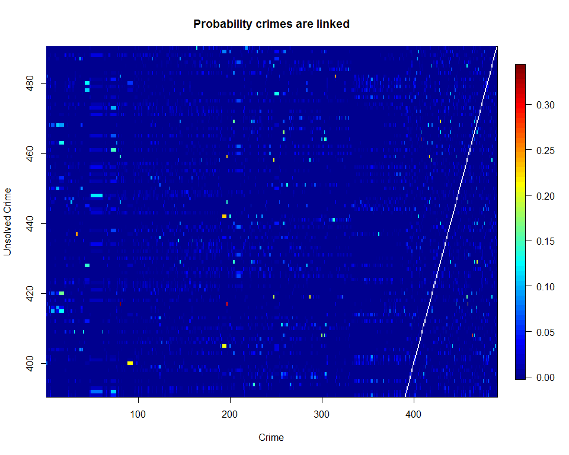

```r
library(fields) # if not installed, type: install.packages("fields")

#-- Get index of unsolved crimes
ind.unsolved = which(is.na(A$CG))          # index of unsolved crimes
n = nrow(A)                                # number of crimes

#-- Image plot of linkage probabilities
fields::image.plot(1:n,ind.unsolved,pp[1:n,ind.unsolved],
           xlab="Crime",ylab="Unsolved Crime",
           main="Probability crimes are linked")
```

We see that some unsolved crimes are linked to solved crimes with a posterior probability above `0.25`. These crimes may be worth further investigations.

Here we plot the maximum posterior probability that an unsolved crime is linked to another crime (solved or unsolved).

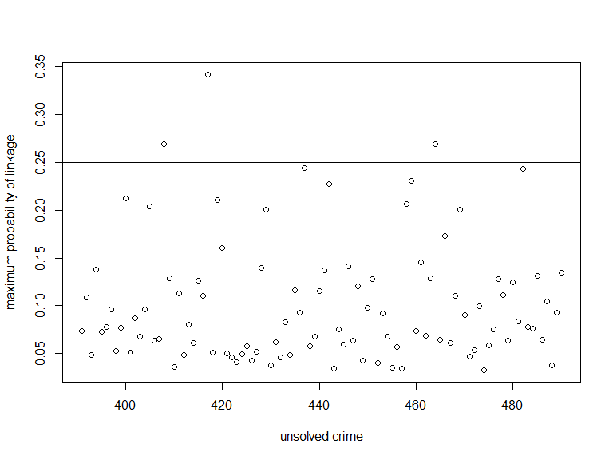

```r
#-- Find strongest linkages
unsolved.probs = apply(pp[ind.unsolved,],1,max,na.rm=TRUE)  # maximum probability
plot(ind.unsolved,unsolved.probs,xlab="unsolved crime",ylab='maximum probability of linkage')
abline(h=0.25)
```

```r
ind = ind.unsolved[unsolved.probs > 0.25]
investigate = as.character(A$crimeID[ind])       # crimeIDs for crimes with strongest linkage
investigate
```

```
#> [1] "C:408" "C:417" "C:464"
```

This shows that `C:408, C:417, C:464` are the crimes with the strongest linkages (posterior probabilities greater that 0.25). A particular crime can be investigated in more detail with the function `bayesProb()`:

```r
bp = bayesProb(pp[A$crimeID %in% "C:417"])
bp$crimeID = A$crimeID[bp$index]
bp$CG = A$CG[bp$index]
head(bp)
```

```
#>   index       prob crimeID  CG
#> 1    81 0.34155556    C:15  46
#> 2   197 0.29111111    C:26 146
#> 3   459 0.22222222   C:459  NA
#> 4   446 0.10255556   C:446  NA
#> 5     2 0.04900000    C:10   2
#> 6   482 0.04888889   C:482  NA
```

For this example, our model provides a list of the most likely crimes associated with the unsolved crime `C:417`. The first two crimes (C:15 and C:26) are solved crimes indicating that the offender(s) responsible for these crimes may also be responsible for C:417. The next two crimes, C:459 and C:446 do not have a group ID. This means that they are unsolved crimes. By providing the posterior probabilities, crime analysts may choose to investigate further only if the linkage is strong enough.

References

Adderley, R., and P. Musgrove. 2003. “Modus Operandi Modelling of Group Offending: A Data-Mining Case Study.” *International Journal of Police Science & Management* 5 (4). Vathek Publishing: 265–76.

Adderley, Richard. 2004. “The Use of Data Mining Techniques in Operational Crime Fighting.” In *Intelligence and Security Informatics*, edited by Hsinchun Chen, Reagan Moore, Daniel Zeng, and John Leavitt, 3073:418–25. Lecture Notes in Computer Science. Springer Berlin / Heidelberg.

Reich, Brian J, and Michael D Porter. 2015. “Partially-Supervised Spatiotemporal Clustering for Crime Series Identification.” *Journal of the Royal Statistical Society: Series A (Statistics in Society)* 178 (2): 465–80. http://onlinelibrary.wiley.com/doi/10.1111/rssa.12076/abstract.